# AllLife_Credit_Card_Customer_Segmentation_Project

### AllLife Credit Card Customer Segmentation Project

**Objective: To identify different segments in the existing customer based on their spending patterns as well as past interaction with the bank.**

**Key Questions**

> 1. How many different segments of customers are there?
> 2. How are these segments different from each other?`
> 3. What are your recommendations to the bank on how to better market to and service these customers?

**Data Description:** `Data is of various customers of a bank with their credit limit, the total number of credit cards the customer has, and different channels through which customer has contacted the bank for any queries, different channels include visiting the bank, online and through a call centre.`

```python
import warnings
warnings.filterwarnings('ignore')
```

```python
#importing some relevant libraries
%matplotlib inline
import numpy as np
import pandas as pd
import matplotlib.pyplot as plt
import seaborn as sns
```

```python
df = pd.read_excel('Credit Card Customer Data.xlsx') # Data import
df.head()
```

|  | Sl_No | Customer Key | Avg_Credit_Limit | Total_Credit_Cards | Total_visits_bank | Total_visits_online | Total_calls_made |
| --- | --- | --- | --- | --- | --- | --- | --- |
| 0 | 1 | 87073 | 100000 | 2 | 1 | 1 | 0 |
| 1 | 2 | 38414 | 50000 | 3 | 0 | 10 | 9 |
| 2 | 3 | 17341 | 50000 | 7 | 1 | 3 | 4 |
| 3 | 4 | 40496 | 30000 | 5 | 1 | 1 | 4 |
| 4 | 5 | 47437 | 100000 | 6 | 0 | 12 | 3 |

```python
# Ensuring all columns names are seperated by underscore(_) for uniformity. Customer key column name would be changed.

labels = list(df.columns)
labels[1] = labels[1].replace(' ', '_')
df.columns = labels
df.head(3)
```

|  | Sl_No | Customer_Key | Avg_Credit_Limit | Total_Credit_Cards | Total_visits_bank | Total_visits_online | Total_calls_made |
| --- | --- | --- | --- | --- | --- | --- | --- |
| 0 | 1 | 87073 | 100000 | 2 | 1 | 1 | 0 |
| 1 | 2 | 38414 | 50000 | 3 | 0 | 10 | 9 |
| 2 | 3 | 17341 | 50000 | 7 | 1 | 3 | 4 |

```python
#dropping the SI_No (Serial number column as it is not usefull in the analysis)
df = df.drop(['Sl_No'], axis = 1)
df.head(3)
```

|  | Customer_Key | Avg_Credit_Limit | Total_Credit_Cards | Total_visits_bank | Total_visits_online | Total_calls_made |
| --- | --- | --- | --- | --- | --- | --- |
| 0 | 87073 | 100000 | 2 | 1 | 1 | 0 |
| 1 | 38414 | 50000 | 3 | 0 | 10 | 9 |
| 2 | 17341 | 50000 | 7 | 1 | 3 | 4 |

## EDA

```python
# rows and column in data

print(f'This dataset has {df.shape[0]} rows and {df.shape[1]} columns.')
```

```
This dataset has 660 rows and 6 columns.
```

```python
#check for missing value in both columns and rows
df.isnull().sum()
```

```
Customer_Key           0
Avg_Credit_Limit       0
Total_Credit_Cards     0
Total_visits_bank      0
Total_visits_online    0
Total_calls_made       0
dtype: int64
```

```python
# extract information about the columns
df.info()
```

```
<class 'pandas.core.frame.DataFrame'>
RangeIndex: 660 entries, 0 to 659
Data columns (total 6 columns):
Customer_Key           660 non-null int64
Avg_Credit_Limit       660 non-null int64
Total_Credit_Cards     660 non-null int64
Total_visits_bank      660 non-null int64
Total_visits_online    660 non-null int64
Total_calls_made       660 non-null int64
dtypes: int64(6)
memory usage: 31.1 KB
```

```python
# Statistical checks using describe functions
df.describe()
```

|  | Customer_Key | Avg_Credit_Limit | Total_Credit_Cards | Total_visits_bank | Total_visits_online | Total_calls_made |
| --- | --- | --- | --- | --- | --- | --- |
| count | 660.000000 | 660.000000 | 660.000000 | 660.000000 | 660.000000 | 660.000000 |
| mean | 55141.443939 | 34574.242424 | 4.706061 | 2.403030 | 2.606061 | 3.583333 |
| std | 25627.772200 | 37625.487804 | 2.167835 | 1.631813 | 2.935724 | 2.865317 |
| min | 11265.000000 | 3000.000000 | 1.000000 | 0.000000 | 0.000000 | 0.000000 |
| 25% | 33825.250000 | 10000.000000 | 3.000000 | 1.000000 | 1.000000 | 1.000000 |
| 50% | 53874.500000 | 18000.000000 | 5.000000 | 2.000000 | 2.000000 | 3.000000 |
| 75% | 77202.500000 | 48000.000000 | 6.000000 | 4.000000 | 4.000000 | 5.000000 |
| max | 99843.000000 | 200000.000000 | 10.000000 | 5.000000 | 15.000000 | 10.000000 |

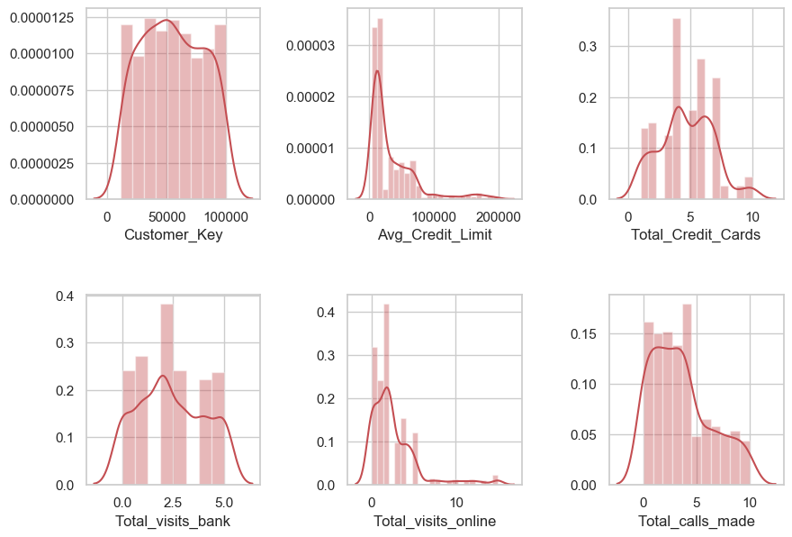

```python
fig = plt.figure(figsize=[10,7], dpi=100)
fig.subplots_adjust(hspace=0.5, wspace=0.5)
sns.set_style("whitegrid")
col = df.columns.tolist()
j = 1
for i in col:
    ax = fig.add_subplot(2,3,j)
    sns.distplot(df[i], ax=ax, color = 'r', kde =True)
    j = j+1
    if j>len(col):
        break
plt.show()
```

**The following Observations could be deduced from the above plots**

> 1. Average credit limit data seems to have 3 distinct groups (clusters)
> 2. Total Credit Card data seems to have 5 distinct clusters
> 3. Total Visits to bank data exhibits 3 distinct clusters
> 4. Total visit online also exhibit 3 or 4 clusters
> 5. Total calls made seems to have 2 groups/ clusters
> 6. The customer key information appears to have 2 clusters. It's relevance would be investigated subsequently.

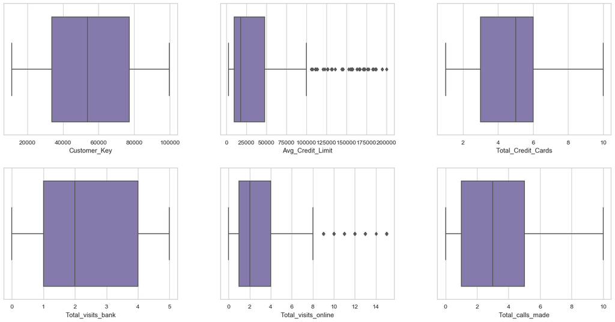

```python
fig = plt.figure(figsize=[20,10], dpi=90)
fig.subplots_adjust(hspace=0.25, wspace=0.25)
sns.set_style("whitegrid")

columns = ['Customer_Key','Avg_Credit_Limit','Total_Credit_Cards','Total_visits_bank','Total_visits_online','Total_calls_made']
j = 1
for i in columns:
    ax = fig.add_subplot(2,3,j)
    sns.boxplot(df[i], ax=ax, color = 'm')
    j = j+1
    if j>len(columns):
        break
plt.show()
```

`The outliers are not significant`

```python
df.columns.to_list()
df[df.columns.to_list()].nunique()
```

```
Customer_Key           655
Avg_Credit_Limit       110
Total_Credit_Cards      10
Total_visits_bank        6
Total_visits_online     16
Total_calls_made        11
dtype: int64
```

`From the unique function, the higher the number of unique values, the less distinct the clusters would be, for example, the Customer_Key with highest unique values don't have distinct clusters visually`

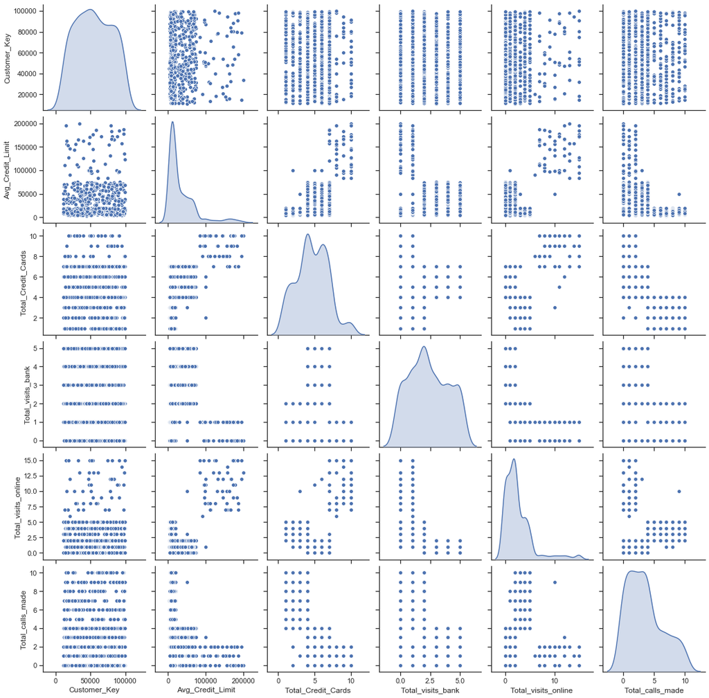

```python
# Pair plot gives 2D view of clusters between two pair of variables
sns.set(style='ticks',font_scale=1);
sns.pairplot(df, diag_kind='kde');
```

**Observations from pair plot**

> Generally, 3 clusters could be seen when data distribution is viewed pair-wise. For example, the following could be deduced from the chart:
> 1. total_visit_online vs Avg_credit_limit & Total_credit_card has 2 distinct clusters
> 2. Up to 3 clusters can be seen between Total_visit_online vs Total_calls_made, Total_calls_made vs Total_credit_cards, and Total_credit_cards vs Avg_credit_limit

## Executing K-means Clustering

```python
##Scale the data
from scipy.stats import zscore

df_zscore = df.apply(zscore)
```

#### Using all data including Customer_key columns for elbow analysis

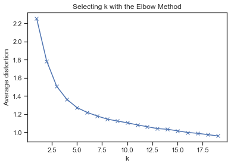

```python
#Finding optimal no. of clusters
from sklearn.cluster import KMeans
from scipy.spatial.distance import cdist
clusters_1=range(1,20)
Avg_Distortions=[]

for k in clusters_1:
    model_1= KMeans(n_clusters=k)
    model_1.fit(df_zscore)
    prediction=model_1.predict(df_zscore)

    # average of the minimum distance between data points and centroid
    Avg_Distortions.append(sum(np.min(cdist(df_zscore, model_1.cluster_centers_, 'euclidean'), axis=1)) / df.shape[0])


plt.plot(clusters_1, Avg_Distortions, 'bx-')
plt.xlabel('k')
plt.ylabel('Average distortion')
plt.title('Selecting k with the Elbow Method')
```

`No distinct elbow seen, K = 7 could be selected if customer_key data is included`

#### droping the Customer_key columns from the data set

```python
df1 = df.drop(['Customer_Key'], axis=1)
df1.head(2)
```

|  | Avg_Credit_Limit | Total_Credit_Cards | Total_visits_bank | Total_visits_online | Total_calls_made |
| --- | --- | --- | --- | --- | --- |
| 0 | 100000 | 2 | 1 | 1 | 0 |
| 1 | 50000 | 3 | 0 | 10 | 9 |

```python
df1_zscore = df1.apply(zscore)
```

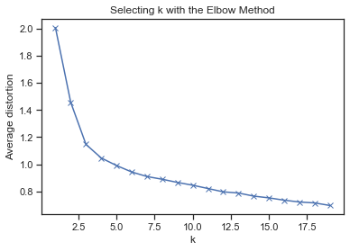

```python
clusters=range(1,20)
meanDistortions=[]

for k in clusters:
    model=KMeans(n_clusters=k)
    model.fit(df1_zscore)
    prediction=model.predict(df1_zscore)
    meanDistortions.append(sum(np.min(cdist(df1_zscore, model.cluster_centers_, 'euclidean'), axis=1)) / df1.shape[0])

plt.plot(clusters, meanDistortions, 'bx-')
plt.xlabel('k')
plt.ylabel('Average distortion')
plt.title('Selecting k with the Elbow Method')
```

`An elbow is seen at K = 3. Comparatively, the average distortion is lower than when the Customer_key column was included. It will be okay at this point to proceed without the Customer_key column so as to make maximum sense out of the data`

#### Fit K-means using optimum K value

```python
#Set the value of k=3, data with the customer key dropped would be used.
kmeans_1 = KMeans(n_clusters=3, n_init = 15, random_state=660)
```

```python
kmeans_1.fit(df1_zscore)
```

```
KMeans(algorithm='auto', copy_x=True, init='k-means++', max_iter=300,
       n_clusters=3, n_init=15, n_jobs=None, precompute_distances='auto',
       random_state=660, tol=0.0001, verbose=0)
```

```python
centroids = kmeans_1.cluster_centers_
centroids
```

```
array([[-0.02106178,  0.37368962,  0.6663945 , -0.55367163, -0.55300488],
       [-0.59579625, -1.05962278, -0.9015185 ,  0.32299678,  1.14810882],
       [ 2.83176409,  1.86222621, -1.10576269,  2.82731942, -0.87432983]])
```

###### Creating Data Frame to hold the tables and their predicted clusters or groups`

```python
# Add cluster number to original data (transformed)
predictions = kmeans_1.predict(df1_zscore)
```

```python
df1_zscore["GROUP"] = predictions

#make group to be categorical
df1_zscore['GROUP'] = df1_zscore['GROUP'].astype('category')
```

```python
df1_zscore.head()
```

|  | Avg_Credit_Limit | Total_Credit_Cards | Total_visits_bank | Total_visits_online | Total_calls_made | GROUP |
| --- | --- | --- | --- | --- | --- | --- |
| 0 | 1.740187 | -1.249225 | -0.860451 | -0.547490 | -1.251537 | 0 |
| 1 | 0.410293 | -0.787585 | -1.473731 | 2.520519 | 1.891859 | 1 |
| 2 | 0.410293 | 1.058973 | -0.860451 | 0.134290 | 0.145528 | 0 |
| 3 | -0.121665 | 0.135694 | -0.860451 | -0.547490 | 0.145528 | 0 |
| 4 | 1.740187 | 0.597334 | -1.473731 | 3.202298 | -0.203739 | 2 |

```python
# Original Data with Groups
df1['GROUP'] = predictions
df1.head()
```

|  | Avg_Credit_Limit | Total_Credit_Cards | Total_visits_bank | Total_visits_online | Total_calls_made | GROUP |
| --- | --- | --- | --- | --- | --- | --- |
| 0 | 100000 | 2 | 1 | 1 | 0 | 0 |
| 1 | 50000 | 3 | 0 | 10 | 9 | 1 |
| 2 | 50000 | 7 | 1 | 3 | 4 | 0 |
| 3 | 30000 | 5 | 1 | 1 | 4 | 0 |
| 4 | 100000 | 6 | 0 | 12 | 3 | 2 |

#### Box plot for K-Means clustering

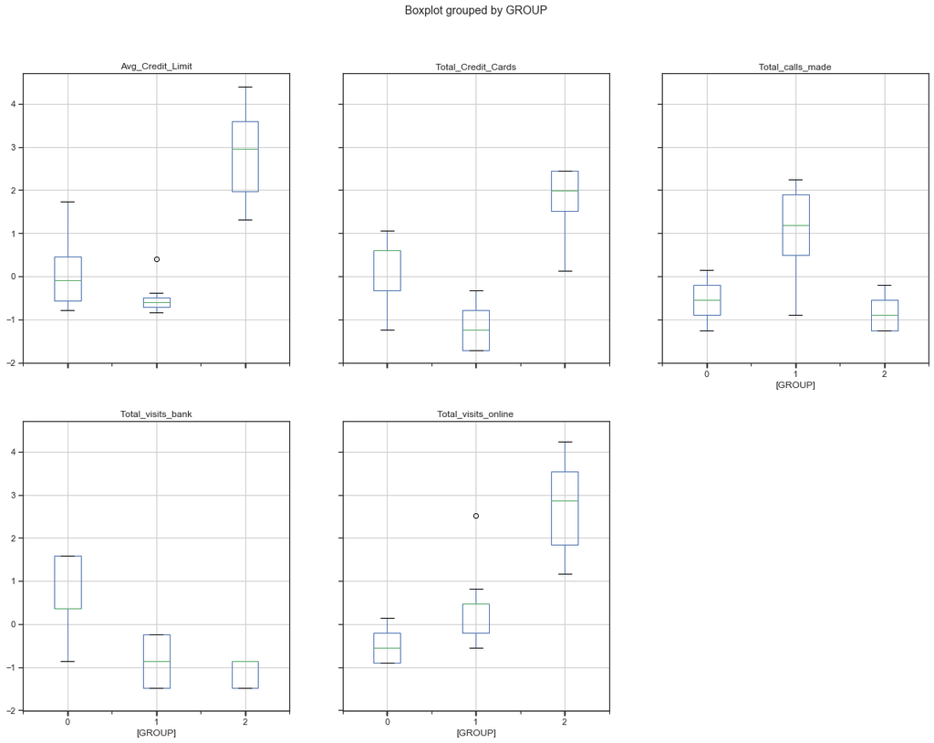

```python
df1_zscore.boxplot(by = 'GROUP',  layout=(2,3), figsize=(20, 15));
```

## Executing Hierarchical Clustering

```python
from sklearn.cluster import AgglomerativeClustering
from scipy.cluster.hierarchy import cophenet, dendrogram, linkage
from scipy.spatial.distance import pdist  #Pairwise distribution between data points
df_H_z = df1_zscore.drop('GROUP', axis = 1)  # drop the GROUP column initially inserted
df_H_z.head()
```

|  | Avg_Credit_Limit | Total_Credit_Cards | Total_visits_bank | Total_visits_online | Total_calls_made |
| --- | --- | --- | --- | --- | --- |
| 0 | 1.740187 | -1.249225 | -0.860451 | -0.547490 | -1.251537 |
| 1 | 0.410293 | -0.787585 | -1.473731 | 2.520519 | 1.891859 |
| 2 | 0.410293 | 1.058973 | -0.860451 | 0.134290 | 0.145528 |
| 3 | -0.121665 | 0.135694 | -0.860451 | -0.547490 | 0.145528 |
| 4 | 1.740187 | 0.597334 | -1.473731 | 3.202298 | -0.203739 |

##### Running analysis with different linkages and comparing the resultant cophenet index to get the best linkage method and dendogram

```python
# cophenet index is a measure of the correlation between the distance of points in feature space and distance on dendrogram
# closer it is to 1, the better is the clustering
c = []
linkage_methods = ['single', 'complete','average','weighted','centroid','ward']
for i in linkage_methods:
    Z = linkage(df_H_z, metric='euclidean', method= i)
    c.append(cophenet(Z, pdist(df_H_z)))
pd.DataFrame(c, columns =['cophenetic coef', 'array'], index = linkage_methods).drop('array', axis = 1)
```

|  | cophenetic coef |
| --- | --- |
| single | 0.739122 |
| complete | 0.859973 |
| average | 0.897708 |
| weighted | 0.886175 |
| centroid | 0.893939 |
| ward | 0.741516 |

#### Dendogram plot for each Linkage method considered

```python
# Finding the linkage for each linkage method
Z_single = linkage(df_H_z, metric='euclidean', method='single')
Z_complete = linkage(df_H_z, metric='euclidean', method='complete')
Z_average = linkage(df_H_z, metric='euclidean', method='average')
Z_weighted = linkage(df_H_z, metric='euclidean', method='weighted')
Z_centroid = linkage(df_H_z, metric='euclidean', method='centroid')
Z_ward = linkage(df_H_z, metric='euclidean', method='ward')
```

##### (1) Single Linkage Method

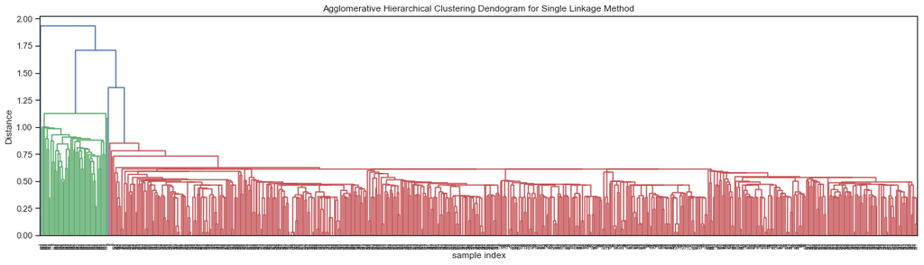

```python
# Plotting Dendogram for each linkage method

plt.figure(figsize=(17, 5))
plt.title('Agglomerative Hierarchical Clustering Dendogram for Single Linkage Method')
plt.xlabel('sample index')
plt.ylabel('Distance')
dendrogram(Z_single)
plt.tight_layout()
```

##### (2) Complete Linkage Method

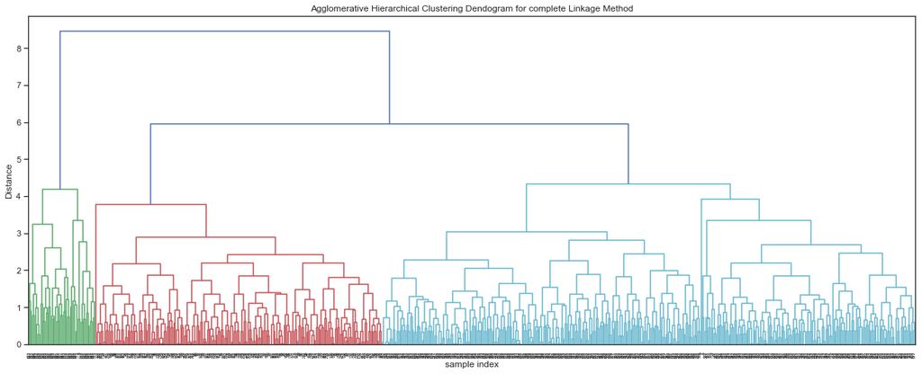

```python
plt.figure(figsize=(17, 7))
plt.title('Agglomerative Hierarchical Clustering Dendogram for complete Linkage Method')
plt.xlabel('sample index')
plt.ylabel('Distance')
dendrogram(Z_complete)
plt.tight_layout()
```

##### (3) Average Linkage Method

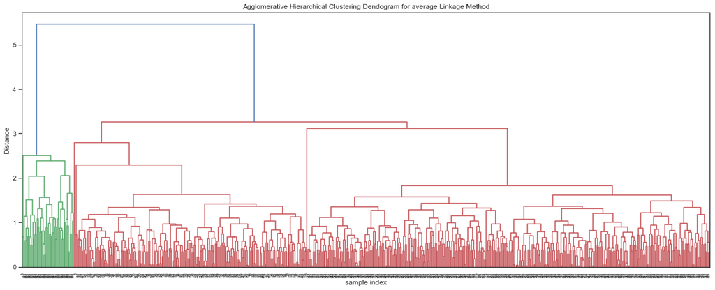

```python
plt.figure(figsize=(17, 7))
plt.title('Agglomerative Hierarchical Clustering Dendogram for average Linkage Method')
plt.xlabel('sample index')
plt.ylabel('Distance')
dendrogram(Z_average)
plt.tight_layout()
```

##### (4) Weighted Linkage Method

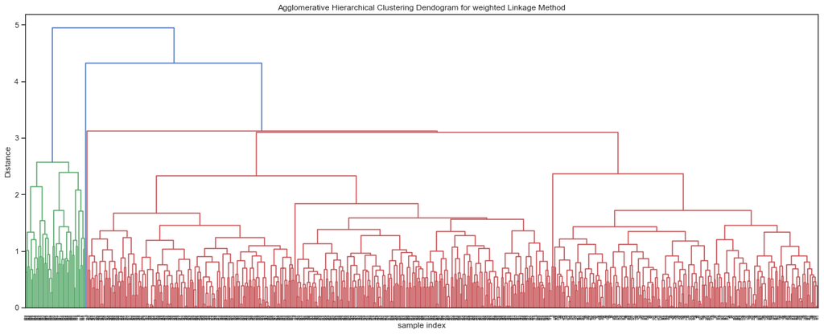

```python
plt.figure(figsize=(17, 7))
plt.title('Agglomerative Hierarchical Clustering Dendogram for weighted Linkage Method')
plt.xlabel('sample index')
plt.ylabel('Distance')
dendrogram(Z_weighted)
plt.tight_layout()
```

##### (5) Centroid Linkage Method

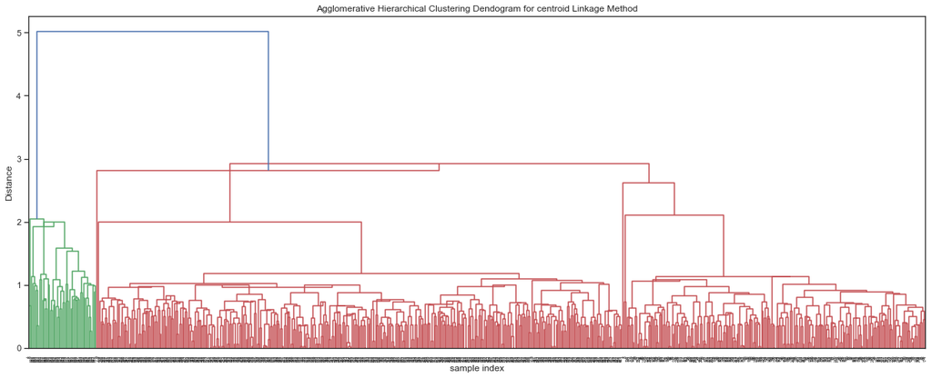

```python
plt.figure(figsize=(17, 7))
plt.title('Agglomerative Hierarchical Clustering Dendogram for centroid Linkage Method')
plt.xlabel('sample index')
plt.ylabel('Distance')
dendrogram(Z_centroid)
plt.tight_layout()
```

##### (6) Ward Linkage Method

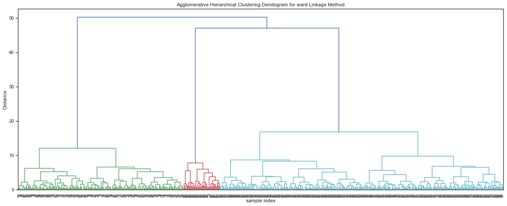

```python
plt.figure(figsize=(17, 7))
plt.title('Agglomerative Hierarchical Clustering Dendogram for ward Linkage Method')
plt.xlabel('sample index')
plt.ylabel('Distance')
dendrogram(Z_ward)
plt.tight_layout()
```